# bitcoin_data

### Exploring the bitcoin dataset

In this notebook we take a look at the bitcoin transaction dataset.

First we open the edge-list file and get the edges in the graph.

```python
file = open("elliptic_bitcoin_dataset/elliptic_txs_edgelist.csv")
header = file.readline()

pairs = [] ## edge list

for line in file.readlines():
    a,b = map(int,line.strip().split(','))
    pairs.append([a,b])
```

```python
pairs[:4]
```

```
[[230425980, 5530458],
 [232022460, 232438397],
 [230460314, 230459870],
 [230333930, 230595899]]
```

### Connected components

The graph for this dataset is massive. In the code below we break it down into connected components.

```python
## DFS code adapted from here:https://stackoverflow.com/questions/42251308/python-connected-components-edges-list
adj_list = dict()# // adjacency list
vis = dict() #// visited_list
connected_components = [] #// contains all the connected components
temp_component = []
component = dict()  ## associate node to its component

def dfs( node ):
    vis[node] = True
    temp_component.append(node)
    component[node] = temp_component
    for neighbour in adj_list[node]:
        if vis[neighbour] == False:
            dfs(neighbour)

for a,b in pairs:
    try:
        adj_list[a].append(b)
    except:
        adj_list[a] = []
    try:
        adj_list[b].append(a)
    except:
        adj_list[b] = []
    vis[a] = False
    vis[b] = False


for a,b in pairs:
    temp_component = []
    if vis[a] == False:
        dfs(a)
    if len(temp_component) > 0:
        connected_components.append(temp_component)
```

```python
## There are 41898 connected components
len(connected_components)
```

```
41898
```

```python
## This is the number of edges in the total graph
len(pairs)
```

```
234355
```

### Examining a particular component

In the code below we sort the connected components by size (descending order).

It happens to have 100 nodes.

```python
sorted_components=sorted(connected_components,key = lambda x : len(x),reverse=True)
```

```python
CC = sorted_components[55]
print(len(CC))

## The edges relevant to this component
cc_pairs = [(a,b) for (a,b) in pairs if a in CC]
```

```
100
```

### A visualization

In the cell below we use the `networkx` library to make a plot of the graph.

I am not very happy with this image -- I tried for awhile to get the graph to plot in "topologically sorted" layout, which would be a more natural picture in this case.

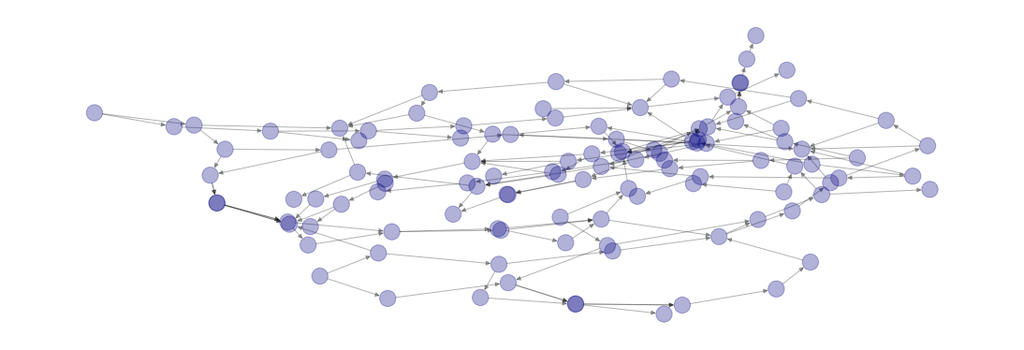

```python
import numpy as np
import networkx as nx
import matplotlib.pyplot as plt

plt.figure(figsize=(15,5))

G = nx.DiGraph()
G.add_edges_from(cc_pairs)

nx.draw(G, cmap = plt.get_cmap('jet'),pos=nx.kamada_kawai_layout(G), node_color = np.ones(G.order()),alpha=0.3)
plt.show()
```

### Adding signal data

Now we color the image of the graph. It turns out that in this subgraph there are only nodes of type "licit" and "unknown".

That is, there are no illicit transactions in this connected component.

The red nodes represent "licit" transactions, and the purple nodes represent transactions of unknown status.

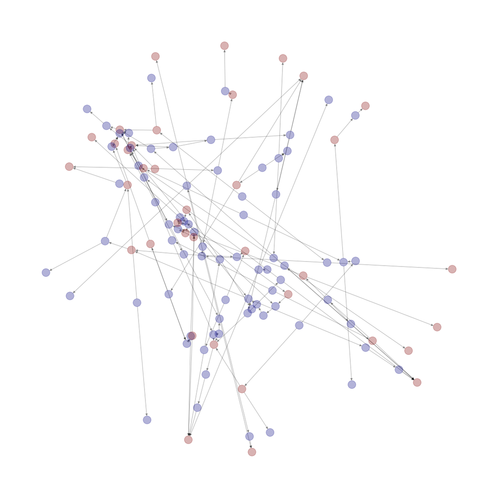

```python
file=open("elliptic_bitcoin_dataset/elliptic_txs_classes.csv","r")
header=file.readline()
signal = dict()
for line in file.readlines():
    L = line.strip().split(',')
    node = int(L[0])
    try:
        status = int(L[1])
    except:
        status = 0 ## unknown
    signal[node]=status

file.close()

plt.figure(figsize=(15,15))
nx.draw(G, cmap = plt.get_cmap('jet'), node_color =[signal[g] for g in G.nodes()],alpha=0.3)
plt.show()
```

### A wider net

It turns out most connected components have no illicit transactions.

The 2nd largest connected component is an example of a component where illicit transactions are present.

Ironically, the plotting software colors these as "green".

```
{0, 1, 2}
```

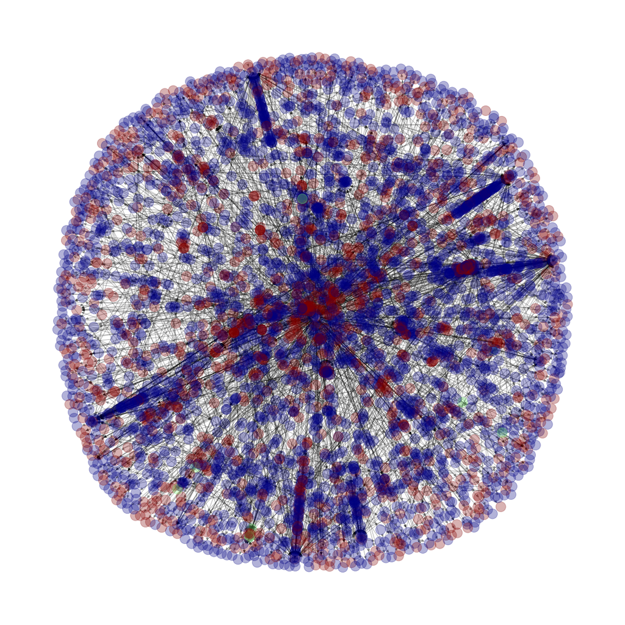

```python
CC = sorted_components[1]

## The edges relevant to this component
cc_pairs = [(a,b) for (a,b) in pairs if a in CC]

plt.figure(figsize=(15,5))

G = nx.DiGraph()
G.add_edges_from(cc_pairs)

print(set([signal[g] for g in G.nodes()]))
plt.figure(figsize=(15,15))
nx.draw(G, cmap = plt.get_cmap('jet'), node_color =[signal[g] for g in G.nodes()],alpha=0.3)
plt.show()
```

### Thoughts on the bitcoin dataset

The graph signal we get on this graph of transactions is not very "smooth". I think that this is a challenging dataset.

There are other features known about these transactions that we are not using. In this notebook we are looking exclusively at the graph structure.

If we can use graph data to improve conventional methods of classifying the transactions based on the extended data then this would still be a win, even if the technique did not work very well directly on the graph.